# Empleo según género en América Latina

Fernanda López Franz

## Introducción

Contamos con datos sobre Tipo de Empleo según Género (que toman en consideración la clasificación mujeres-hombres) para los años comprendidos entre 1991 y 2018.

El informe cuenta con **52 variables**, y **460 observaciones**. Las variables se refieren al tipo de trabajo y son las siguientes.

| Variables |
| --- |
| empleadoras_mujeres |
| empleadores_hombres |
| empleo_agricultura_mujeres |
| empleo_agricultura_hombres |
| empleo_industria_mujeres |
| empleo_industria_hombres |
| empleo_servicios_mujeres |
| empleo_servicios_hombres |
| empleo_informal_mujeres |
| empleo_informal_hombres |
| legislacion_acoso_sexual |
| autoempleo_mujeres |
| autoempleo_hombres |
| empleo_parcial_mujeres |
| desempleo_educacion_mujeres |
| desempleo_educacion_hombres |
| desempleo_mujeres |
| desempleo_hombres |
| trabajo_domestico_no_remunerado_mujeres |
| trabajo_domestico_no_remunerado_hombres |

Respecto a los países y regiones analizadas, la tabla contiene datos para países de América Latina y el Caribe, España y mundiales. Nos quedaremos con los datos referidos a países latinoamericanos y del Caribe (excluimos entonces a “España”, “Mundo” y “Latin America and Carribbean). Una primera dificultad reside en que no se cuenta con datos disponibles para todos los años analizados y, como veremos más adelante cuando analicemos el caso de Argentina, para algunos casos no se cuenta con información para determinadas variables para algunos años.

**AMERICA LATINA Y EL CARIBE**

En primer lugar, vamos a analizar la variable Empleo Informal Mujeres, para América Latina y el Caribe. Tomaremos el período comprendido entre 2008 y 2018, puesto que identificamos que durante esta década contamos con mayor cantidad de datos. Algunas preguntas que guiarán el desarrollo son:

1. ¿Cuál es la media de mujeres con empleo informal para la región analizada?
2. ¿Cuál es el país con el mayor y el menor promedio?
3. ¿Qué años presentan mayor empleo informal en mujeres, para la región analizada?
4. ¿Cuál es el desvio para cada uno de los países analizados, respecto del valor medio?

# Media de empleo informal, en mujeres

La media de empleo informal de mujeres para la región analizada, para los años que van entre 2008 y 2018 es de **59.80**.

| Total media informal mujeres |
| --- |
| 59.80953 |

# Valores mínimos y máximos por país, sin años agrupados

Si analizamos los datos por país, podemos observar que el país con la media de empleo informal de mujeres más alta es Guatemala: 79,26. Mientras que el país con la menor media de empleo informal de mujeres, es Chile: 29,94.

| País | Media de empleo informal, mujeres |
| --- | --- |
| Guatemala | 79.26250 |
| Bolivia | 78.96111 |
| Nicaragua | 78.69000 |
| Honduras | 75.48300 |
| Perú | 71.50900 |
| El Salvador | 71.39875 |
| Paraguay | 69.61500 |
| Ecuador | 66.39364 |
| Colombia | 61.49000 |
| República Dominicana | 53.58000 |
| Argentina | 48.59625 |
| Costa Rica | 41.26667 |
| Panamá | 39.84714 |
| Brasil | 38.39167 |
| Uruguay | 31.61800 |
| Chile | 29.94000 |
| Cuba | NaN |
| Haití | NaN |
| México | NaN |
| Venezuela | NaN |

# Valores mínimos y máximos por país, con años agrupados

Sin embargo, si evaluamos los valores máximos y los valores mínimos agrupando todos los años, vemos que el valor máximo de empleo informal de mujeres corresponde a Bolivia con 82,45, seguido sí, por Guatemala con 82,40.

| País | Valor máx empleo informal |
| --- | --- |
| Bolivia | 82.45 |
| Guatemala | 82.40 |
| Perú | 79.69 |
| Nicaragua | 78.69 |
| Honduras | 78.05 |
| Ecuador | 76.14 |
| Paraguay | 74.24 |
| El Salvador | 72.25 |
| Colombia | 65.18 |
| República Dominicana | 57.29 |
| Argentina | 51.67 |
| Brasil | 43.83 |
| Costa Rica | 43.65 |
| Panamá | 42.20 |
| Uruguay | 41.13 |
| Chile | 29.94 |
| Cuba | -Inf |
| Haití | -Inf |
| México | -Inf |
| Venezuela | -Inf |

El valor mínimo corresponde a Uruguay con **22,61**, seguido por Chile con **29,94**.

| País | Valor mínimo empleo informal, mujeres |
| --- | --- |
| Uruguay | 22.61 |
| Chile | 29.94 |
| Brasil | 36.16 |
| Costa Rica | 37.20 |
| Panamá | 37.90 |
| Argentina | 46.47 |
| República Dominicana | 51.65 |
| Colombia | 58.07 |
| Ecuador | 60.65 |
| Perú | 65.36 |
| Paraguay | 66.01 |
| El Salvador | 69.34 |
| Honduras | 71.97 |
| Bolivia | 75.02 |
| Guatemala | 76.73 |
| Nicaragua | 78.69 |
| Cuba | Inf |
| Haití | Inf |
| México | Inf |
| Venezuela | Inf |

# Desvío estándar

Ahora veamos el desvío estandar: el país que más se aleja de la media es **Uruguay.**

| País | Desvío |
| --- | --- |
| Uruguay | 7.753761 |
| Perú | 5.677262 |
| Ecuador | 4.631631 |
| Paraguay | 3.106052 |
| Colombia | 2.831713 |
| Brasil | 2.796144 |
| Honduras | 2.224780 |
| Costa Rica | 2.165456 |
| Bolivia | 2.069332 |
| Guatemala | 1.937110 |
| Argentina | 1.801657 |
| República Dominicana | 1.575867 |
| Panamá | 1.380902 |
| El Salvador | 1.094891 |
| Chile | NA |
| Cuba | NA |
| Haití | NA |
| México | NA |
| Nicaragua | NA |
| Venezuela | NA |

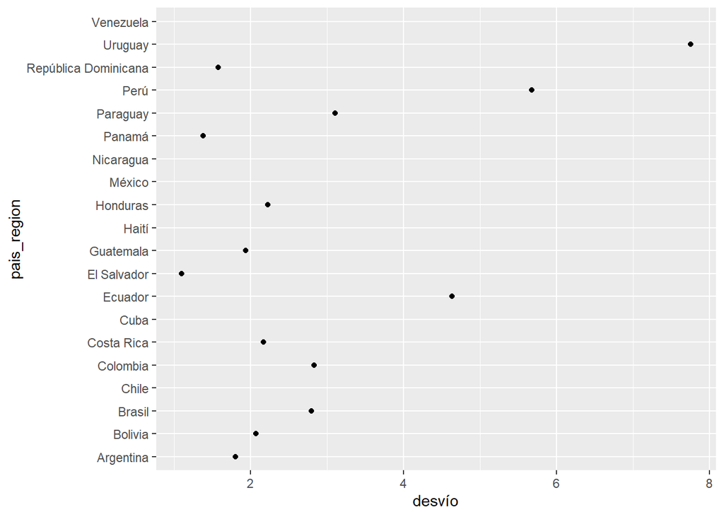

# Mayor media de empleo informal, por año.

Nos interesa saber el año en el que la media de empleo informal de mujeres ha sido más alta. El año **2008**, es el año con *mayor porcentaje de empleo informal de mujeres* para la región considerada (aquí sería interesante saber si este porcentaje tiene relación con los totales de empleo informal respecto al empleo formal,para los países analizados, pero no contamos con los datos).

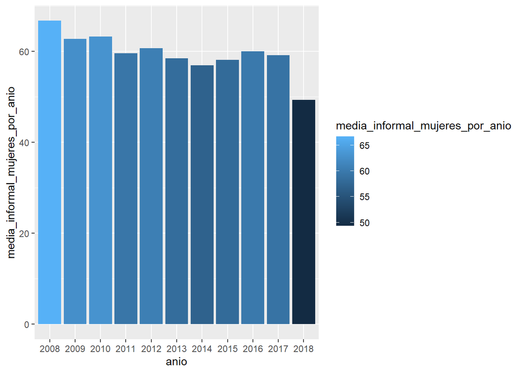

## PREGUNTA (HIPÓTESIS)

El año 2008 fue el año de la crisis financiera global, originada en las Hipotecas de Alto Riesgo en Estados Unidos y otros países, como España ¿está asociada esta crisis con el crecimiento del empleo informal en el año 2008 y los años subsiguientes? Aunque responder esta pregunta requiere considerar un mayor número de factores, como tener en cuenta el comportamiento respecto del empleo formal, podemos comenzar ampliando el rango de años para observar si hay un salto significativo.

| Año | Media de empleo informal, para mujeres |
| --- | --- |
| 2000 | 93.87000 |
| 2001 | 85.00000 |
| 2003 | 79.14750 |
| 2002 | 78.38500 |
| 2004 | 78.11833 |
| 2005 | 76.73200 |
| 2006 | 68.93857 |
| 2008 | 66.74000 |
| 2007 | 66.34000 |
| 2010 | 63.21000 |
| 2009 | 62.71333 |
| 2012 | 60.65800 |
| 2016 | 59.97750 |
| 2011 | 59.56500 |
| 2017 | 59.19231 |
| 2013 | 58.45143 |
| 2015 | 58.14000 |
| 2014 | 56.96786 |
| 2018 | 49.36500 |
| 1998 | NaN |
| 1999 | NaN |

Vemos que en los años previos, y fundamentalmente en los años 2000-2001 el gráfico arroja que la media de empleo informal fue mucho mayor. No obstante, si revisamos los datos disponibles veremos que este dato excepcional se debe a que para esos años sólo se contaban con datos para República Dominicana, con una tasa de empleo informal de mujeres por encima del 90% y Ecuador.

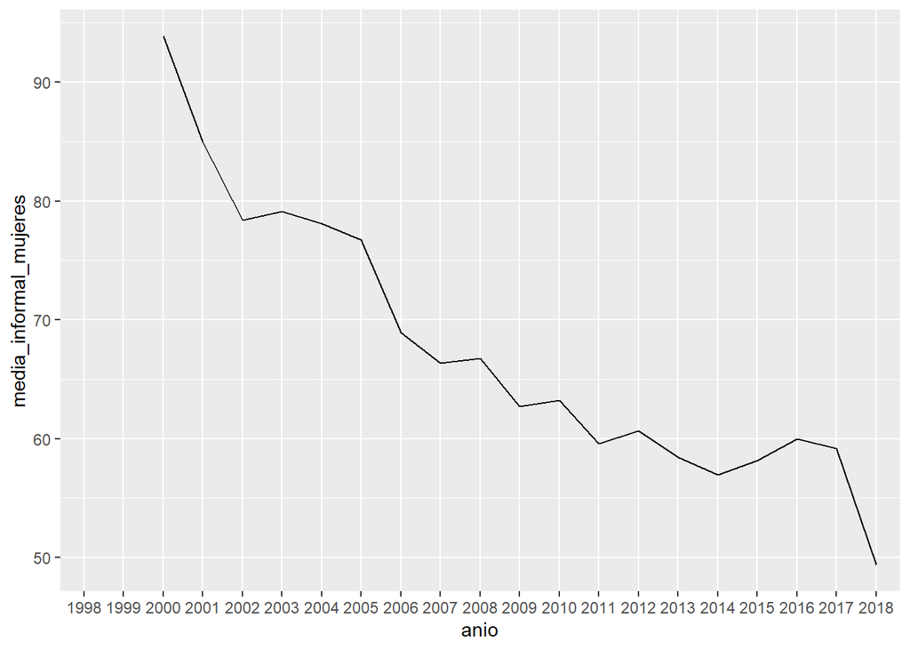

| País | COD | Anio | EI Muj | EI Hom |
| --- | --- | --- | --- | --- |
| República Dominicana | DOM | 2000 | 93.87 | 88.48 |
| República Dominicana | DOM | 2001 | 92.86 | 87.17 |
| Ecuador | ECU | 2001 | 77.14 | 76.31 |
| Argentina | ARG | 2000 | NA | NA |
| Argentina | ARG | 2001 | NA | NA |
| Bolivia | BOL | 2000 | NA | NA |
| Bolivia | BOL | 2001 | NA | NA |
| Brasil | BRA | 2000 | NA | NA |
| Brasil | BRA | 2001 | NA | NA |
| Chile | CHL | 2000 | NA | NA |
| Chile | CHL | 2001 | NA | NA |
| Colombia | COL | 2000 | NA | NA |
| Colombia | COL | 2001 | NA | NA |
| Costa Rica | CRI | 2000 | NA | NA |
| Costa Rica | CRI | 2001 | NA | NA |
| Cuba | CUB | 2000 | NA | NA |
| Cuba | CUB | 2001 | NA | NA |
| Ecuador | ECU | 2000 | NA | NA |
| El Salvador | SLV | 2000 | NA | NA |
| El Salvador | SLV | 2001 | NA | NA |
| Guatemala | GTM | 2000 | NA | NA |
| Guatemala | GTM | 2001 | NA | NA |
| Haití | HTI | 2000 | NA | NA |
| Haití | HTI | 2001 | NA | NA |
| Honduras | HND | 2000 | NA | NA |
| Honduras | HND | 2001 | NA | NA |
| México | MEX | 2000 | NA | NA |
| México | MEX | 2001 | NA | NA |
| Perú | PER | 2000 | NA | NA |
| Perú | PER | 2001 | NA | NA |
| Uruguay | URY | 2000 | NA | NA |
| Uruguay | URY | 2001 | NA | NA |
| Venezuela | VEN | 2000 | NA | NA |
| Venezuela | VEN | 2001 | NA | NA |
| Panamá | PAN | 2000 | NA | NA |
| Panamá | PAN | 2001 | NA | NA |
| Paraguay | PRY | 2000 | NA | NA |
| Paraguay | PRY | 2001 | NA | NA |
| Nicaragua | NIC | 2000 | NA | NA |
| Nicaragua | NIC | 2001 | NA | NA |

En conclusión, con los datos disponibles, la hipótesis no puede ser estudiada debido a la disparidad de datos para los diferentes años.

**ARGENTINA**

En la siguiente sección nos proponemos analizar:

1. ¿Cómo se distribuye el empleo según sector, para el año 2018(último año disponible) para hombres y mujeres?

3. ¿Cuál es la diferencia entre mujeres y varones empleadxs con empleo informal?

4. ¿Cuál es la diferencia entre mujeres y varones que realizan trabajo doméstico no remunerado?

# Distribución de empleo según sector

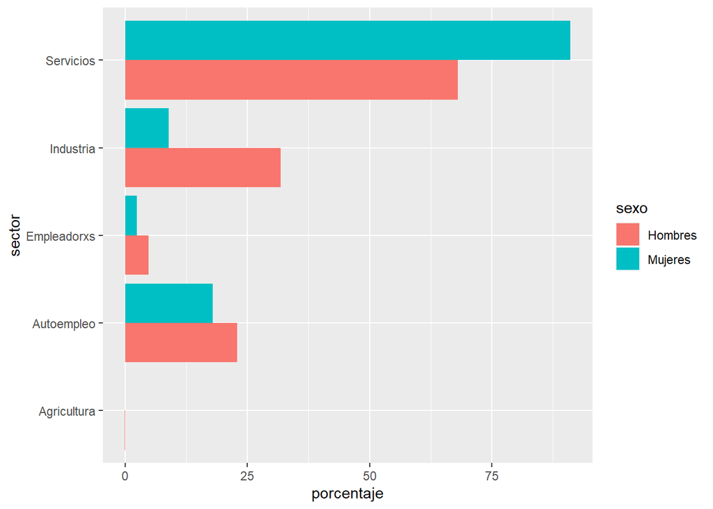

# Empleo informal, mujeres y hombres.

Si comparamos los hombres y mujeres empleadxs con empleo informal, para el año 2017 (último año disponible con datos para Argentina) vemos que no podemos observar diferencias significativas.

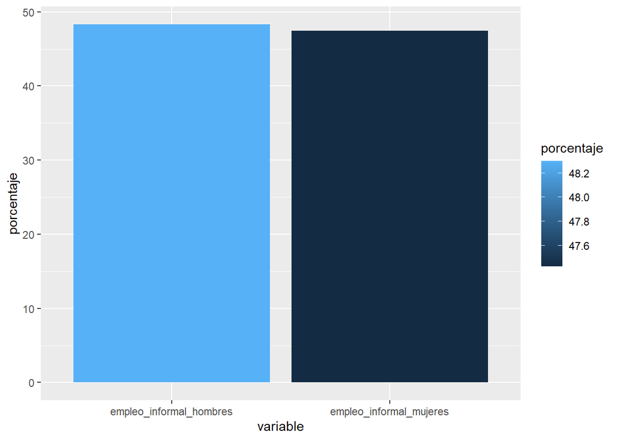

Empleo informal hombres y mujeres.

# Trabajo doméstico no remunerado.

Si analizamos el procentaje de trabajo doméstico no remunerado realizado por hombres en comparación con el trabajo realizado por mujeres (para el año 2013, último año con datos disponibles) vemos que para este punto la diferencia es significativa, dado que el procentaje para mujeres duplica y casi triplica el procentaje para varones.

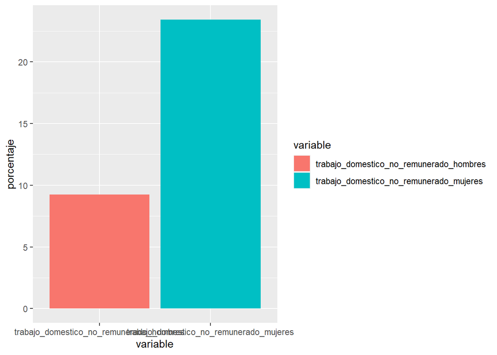

# América Latina

La media de empleo informal de mujeres para la región analizada, para los años que van entre 2008 y 2018 es de **59,80**.

Si analizamos los datos por país, podemos observar que el país con la media de empleo informal de mujeres más alta es Guatemala: 79,26. Mientras que el país con la menor media de empleo informal de mujeres, es Chile: 29,94.

Sin embargo, si evaluamos los valores máximos y los valores mínimos agrupando todos los años, vemos que el valor máximo de empleo informal de mujeres corresponde a Bolivia con 82,45, seguido sí, por Guatemala con 82,40. El valor mínimo corresponde a Uruguay con 22,61, seguido por Chile con 29,94.

El país que más se aleja de la media, es Uruguay.

El año 2008, es el año con mayor porcentaje de empleo informal de mujeres para la región considerada. No podemos responder si existe un salto asociado a la crisis financiera global porque no contamos con información completa para el resto de los años. Además, no contamos con una variable llamada “empleo formal” que nos sirva para comparar.

# Argentina

Si comparamos los *hombres* y *mujeres* empleadxs con *empleo informal*, para el año 2017 (último año disponible con datos para Argentina) vemos que no podemos observar diferencias significativas.

Si analizamos el procentaje de *trabajo doméstico no remunerado* realizado por hombres en comparación con el trabajo realizado por mujeres (para el año 2013, último año con datos disponibles) vemos que para este punto la diferencia es significativa, dado que el procentaje para mujeres duplica y casi triplica el procentaje para varones.